# Sixth Week: Linear Models

House price prediction

Milad Aghajohari 94105474

2018-04-13 23:52:37

> با توجه به داده های قیمت منازل لطفا با سوالات زیر پاسخ دهید.

```r
library(dplyr)
```

```r
library(tidyr)
library(highcharter)
library(psych)
library(ggplot2)
library(corrplot)
```

۱. ماتریس همبستگی متغیرهای مختلف را به دست آورده و سپس رسم نمایید. اعداد به دست آمده را با آزمون فرض معناداری همبستگی بسنجید و سپس ده متغیری که همبستگی بالاتری با قیمت دارند را مشخص نمایید.

Here we will read the data and we will compute correlation matrix between numeric variables(It is meaningless to compute correlation for variables which are not numeric).

```r
train <- read.csv("~/university/Data_Analysis/hw_06/house/train.csv")
train %>% select(-Id) %>% select_if(is.numeric) -> train.num
cor(train.num, use = "pairwise.complete.obs") -> train.num.cor
```

Here we will plot the correlation matrix graphically. The colors are self explanatory.

```r
hchart(train.num.cor)
```

[interactive chart not shown]

Here We will run a correlation test so we can see if the correlation is just meaningful. In plot below we have put an ‘x’ mark on the correlations which aren’t below $2e^{-16}$ so just the very meaningful correlations are remained.

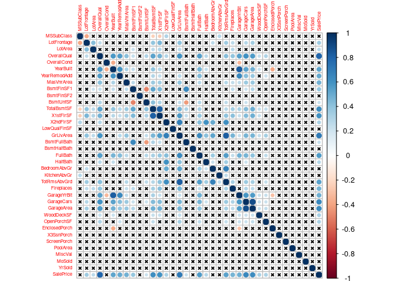

```r
cor.mtest(train.num) -> res1
corrplot(train.num.cor, p.mat = res1$p, sig.level = 2e-16,pch.cex = 0.5, tl.cex = 0.5)
```

Here we will choose ten parameters with most correlation with SalePrice variable.

```r
train.num.cor %>% as.data.frame() -> train.num.cor
train.num.cor %>% select(SalePrice) %>% mutate(param = rownames(.))%>%
  arrange(-abs(SalePrice)) %>% slice(1:11)-> train.sale.factor
train.sale.factor %>% slice(2:11) %>% print()
```

```
## # A tibble: 10 x 2
##    SalePrice param
##        <dbl> <chr>
##  1     0.791 OverallQual
##  2     0.709 GrLivArea
##  3     0.640 GarageCars
##  4     0.623 GarageArea
##  5     0.614 TotalBsmtSF
##  6     0.606 X1stFlrSF
##  7     0.561 FullBath
##  8     0.534 TotRmsAbvGrd
##  9     0.523 YearBuilt
## 10     0.507 YearRemodAdd
```

۲. در یک تصویر نمودار پراکنش دو به دو ده متغیر بدست آمده به همراه قیمت را رسم نمایید و هم خطی بودن متغیرها را بررسی کنید

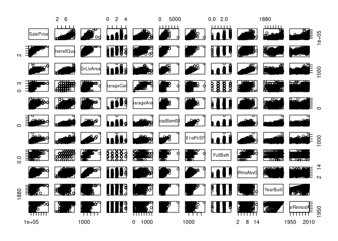

```r
train %>% select(train.sale.factor$param) -> train.sale
train.sale %>% plot()
```

۳. یک مدل خطی بر اساس ده متغیر برای پیش بینی قیمت برازش دهید. و سپس خلاصه نتایج مدل را به دست آورید.

Here we will fit the model and check the summary.

```r
lm(SalePrice ~ ., train.sale) -> model
summary(model)
```

```
##
## Call:
## lm(formula = SalePrice ~ ., data = train.sale)
##
## Residuals:
##     Min      1Q  Median      3Q     Max
## -489958  -19316   -1948   16020  290558
##
## Coefficients:
##                Estimate Std. Error t value Pr(>|t|)
## (Intercept)  -1.186e+06  1.291e+05  -9.187  < 2e-16 ***
## OverallQual   1.960e+04  1.190e+03  16.472  < 2e-16 ***
## GrLivArea     5.130e+01  4.233e+00  12.119  < 2e-16 ***
## GarageCars    1.042e+04  3.044e+03   3.422 0.000639 ***
## GarageArea    1.495e+01  1.031e+01   1.450 0.147384
## TotalBsmtSF   1.986e+01  4.295e+00   4.625 4.09e-06 ***
## X1stFlrSF     1.417e+01  4.930e+00   2.875 0.004097 **
## FullBath     -6.791e+03  2.682e+03  -2.532 0.011457 *
## TotRmsAbvGrd  3.310e+01  1.119e+03   0.030 0.976404
## YearBuilt     2.682e+02  5.035e+01   5.328 1.15e-07 ***
## YearRemodAdd  2.965e+02  6.363e+01   4.659 3.47e-06 ***
## ---
## Signif. codes:  0 '***' 0.001 '**' 0.01 '*' 0.05 '.' 0.1 ' ' 1
##
## Residual standard error: 37920 on 1449 degrees of freedom
## Multiple R-squared:  0.7737, Adjusted R-squared:  0.7721
## F-statistic: 495.4 on 10 and 1449 DF,  p-value: < 2.2e-16
```

۴. نمودار قیمت واقعی و قیمت پیش بینی را رسم نمایید و خوب بودن مدل را ارزیابی کنید.

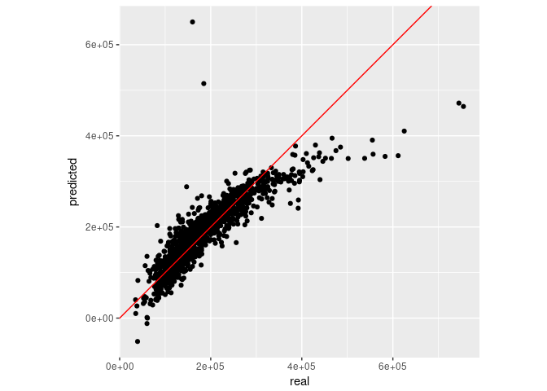

```r
data.frame(predicted = model$fitted.values, real = train.sale$SalePrice, res = model$residuals)->real.est
ggplot(real.est)+geom_point(aes(x = real, y= predicted))+coord_equal()+geom_abline(slope = 1, color = "red")
```

```r
hchart(real.est, type = "scatter", hcaes(x = real, y = res))
```

[interactive chart not shown]

As we can see the model has done well. But we can see the residuals does not follow the Constant Variance rule we assumed while fitting the linear model, Residuals increase by increasing price. As we can see in the model for not very high values the real value and the fitted value are near the (x = y) line which is a good sign we have fitted well but for high values we underestimated the price.

```r
summary(model$residuals)
```

```
##    Min. 1st Qu.  Median    Mean 3rd Qu.    Max.
## -489958  -19316   -1948       0   16020  290558
```

۵. مقدار R-squared مدل را به دست آورید. آیا بر اساس این کمیت مدل به خوبی به داده ها برازش داده شده است؟ کمیت F-statistic را در خلاصه مدل تفسیر نمایید.

```r
model %>% summary() %>% .$adj.r.squared
```

```
## [1] 0.772131
```

These Value is showing we have explained $77.2\%$ of the variance in the date. This shows that the model fitted the data well(but not very well).

```r
model %>% summary() %>% .$fstatistic
```

```
##     value     numdf     dendf
##  495.3802   10.0000 1449.0000
```

Fstatistic is 495. The p-value of these F statistic is less than $2e{-16}$ which shows that the Null Hypothesis of every coefficient being Zero is highly rejected in favor of at least one parameter having non-Zero coefficient.

۶. بر اساس p-value سطح معناداری ضرایب تصمیم بگیرید که چه متغیرهایی در مدل سازی استفاده شود. بر اساس متغیرهای جدید دوباره مدل سازی کنید و نتایج رو گزارش دهید.

```r
train.sale %>% select(-GarageArea,-TotRmsAbvGrd,-FullBath, -X1stFlrSF)->train.sale
lm(SalePrice ~ ., train.sale)->model
summary(model)
```

```
##
## Call:
## lm(formula = SalePrice ~ ., data = train.sale)
##
## Residuals:
##     Min      1Q  Median      3Q     Max
## -477106  -19737   -2015   16452  290098
##
## Coefficients:
##                Estimate Std. Error t value Pr(>|t|)
## (Intercept)  -1.053e+06  1.218e+05  -8.650  < 2e-16 ***
## OverallQual   1.912e+04  1.186e+03  16.123  < 2e-16 ***
## GrLivArea     5.036e+01  2.551e+00  19.743  < 2e-16 ***
## GarageCars    1.439e+04  1.813e+03   7.939 4.03e-15 ***
## TotalBsmtSF   3.086e+01  2.811e+00  10.979  < 2e-16 ***
## YearBuilt     2.211e+02  4.802e+01   4.605 4.49e-06 ***
## YearRemodAdd  2.757e+02  6.353e+01   4.340 1.52e-05 ***
## ---
## Signif. codes:  0 '***' 0.001 '**' 0.01 '*' 0.05 '.' 0.1 ' ' 1
##
## Residual standard error: 38100 on 1453 degrees of freedom
## Multiple R-squared:  0.7709, Adjusted R-squared:   0.77
## F-statistic:   815 on 6 and 1453 DF,  p-value: < 2.2e-16
```

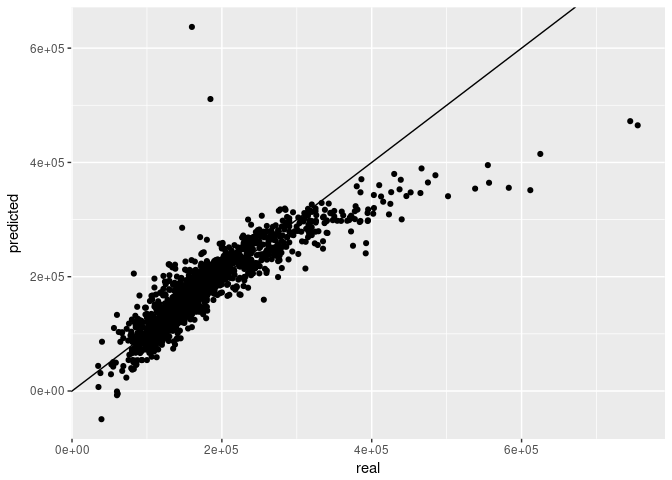

```r
data.frame(predicted = model$fitted.values, real = train.sale$SalePrice, res = model$residuals)->real.est
ggplot(real.est)+geom_point(aes(x = real, y = predicted))+geom_abline(slope = 1)
```

```r
hchart(real.est, type = "scatter", hcaes(x = real, y = res))
```

[interactive chart not shown]

۷. مدل خود را بر اساس باقی مانده نقص یابی کنید. سه محک normality, independance, Constant Variance را در نقص یابی خود در نظر بگیرید.

```r
#Const Var
hchart(real.est, type = "scatter", hcaes(x = real, y = res))
```

[interactive chart not shown]

As you can see in plot above the error term is not constant. To cure this we will predict $log(SalePrice)$ from now on.

```r
#so constant varicance in error term is rejected
train.sale %>% mutate(SalePrice = log(SalePrice)) -> train.sale
lm(SalePrice ~ ., train.sale)->model
summary(model)
```

```
##
## Call:
## lm(formula = SalePrice ~ ., data = train.sale)
##
## Residuals:
##      Min       1Q   Median       3Q      Max
## -2.17204 -0.07530  0.00812  0.09233  0.53923
##
## Coefficients:
##               Estimate Std. Error t value Pr(>|t|)
## (Intercept)  3.118e+00  5.442e-01   5.730 1.22e-08 ***
## OverallQual  9.298e-02  5.300e-03  17.542  < 2e-16 ***
## GrLivArea    2.363e-04  1.140e-05  20.731  < 2e-16 ***
## GarageCars   8.683e-02  8.101e-03  10.719  < 2e-16 ***
## TotalBsmtSF  1.305e-04  1.256e-05  10.389  < 2e-16 ***
## YearBuilt    1.733e-03  2.146e-04   8.074 1.41e-15 ***
## YearRemodAdd 2.153e-03  2.839e-04   7.583 5.98e-14 ***
## ---
## Signif. codes:  0 '***' 0.001 '**' 0.01 '*' 0.05 '.' 0.1 ' ' 1
##
## Residual standard error: 0.1703 on 1453 degrees of freedom
## Multiple R-squared:  0.8191, Adjusted R-squared:  0.8183
## F-statistic:  1096 on 6 and 1453 DF,  p-value: < 2.2e-16
```

```r
data.frame(predicted = exp(model$fitted.values), real = exp(train.sale$SalePrice)) %>% mutate(res = predicted - real)->real.est
hchart(real.est, type = "scatter", hcaes(x = real, y = predicted))
```

[interactive chart not shown]

```r
hchart(real.est, type = "scatter", hcaes(x = real, y = res))
```

[interactive chart not shown]

```r
#VIF
train %>% select(train.sale.factor$param) -> train.sale.vif
lm(SalePrice ~ ., train.sale.vif)->modelvif
library(car)
vif(modelvif)
```

```
##  OverallQual    GrLivArea   GarageCars   GarageArea  TotalBsmtSF
##     2.748629     5.018752     5.250959     4.931012     3.602674
##    X1stFlrSF     FullBath TotRmsAbvGrd    YearBuilt YearRemodAdd
##     3.684726     2.215500     3.356517     2.345827     1.751047
```

As we can see the data is not that normal as it has some shift towards the line.

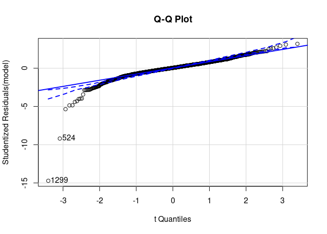

```
## [1]  524 1299
```

```r
#Normailty
car::qqPlot(model, id.methode = "identify", simulate = TRUE, main = "Q-Q Plot")
```

۸. داده ها را به پنج قسمت تقسیم کنید. بر اساس چهار قسمت مدل خطی را بسازید و صحت مدل را برای یک قسمت باقی مانده را تست کنید. خطای پیش بینی شما چقدر است؟

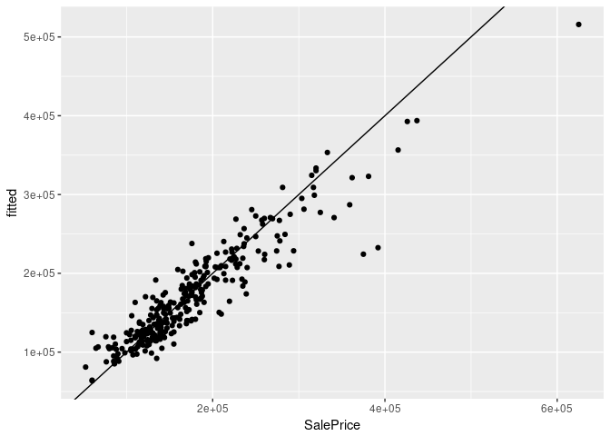

```r
n <- nrow(train.sale)
train.train.index <- sample(1:n,(n*0.8), replace = FALSE)
train.valid.index <- setdiff(1:n, train.train.index)
train.train <- train.sale[train.train.index,]
train.valid <- train.sale[train.valid.index,]
lm(SalePrice~., train.train)->model.lim
predict(model.lim, train.valid) -> train.valid$fitted
train.valid %>% mutate(fitted = exp(fitted), SalePrice = exp(SalePrice)) %>%
  mutate(residual = fitted - SalePrice) -> train.valid
ggplot(train.valid)+geom_point(aes(x = SalePrice, y = fitted))+geom_abline(slope = 1)
```

```r
hchart(train.valid, type = "scatter", hcaes(x = SalePrice, y = residual))
```

[interactive chart not shown]

```r
summary(train.valid$residual)
```

```
##    Min. 1st Qu.  Median    Mean 3rd Qu.    Max.
## -159482  -15888   -1153   -4149   10644   64885
```

۹. آیا قیمت ربط غیر خطی با یکی از ده متغیر استفاده شده دارد؟ بر اساس دستاوردهای خود مدل را بهتر نمایید.

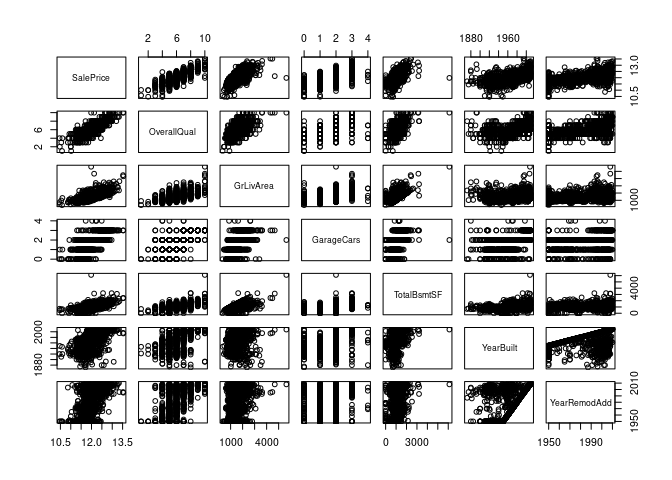

```r
train.sale %>% plot()
```

In my opinion the realtinship between the $SalePrice$ and the $TotalBsmtSf$ is better fitted by an $sqrt$ line. So I can fit these:

```r
lm(SalePrice~.+I(sqrt(TotalBsmtSF)-TotalBsmtSF), train.train)->model.end
summary(model.end)
```

```
##
## Call:
## lm(formula = SalePrice ~ . + I(sqrt(TotalBsmtSF) - TotalBsmtSF),
##     data = train.train)
##
## Residuals:
##      Min       1Q   Median       3Q      Max
## -1.68728 -0.08114  0.00848  0.09598  0.53898
##
## Coefficients:
##                                     Estimate Std. Error t value Pr(>|t|)
## (Intercept)                        2.990e+00  6.165e-01   4.850 1.40e-06
## OverallQual                        9.342e-02  5.993e-03  15.589  < 2e-16
## GrLivArea                          2.404e-04  1.301e-05  18.478  < 2e-16
## GarageCars                         9.077e-02  9.046e-03  10.034  < 2e-16
## TotalBsmtSF                        1.176e-02  1.807e-03   6.510 1.11e-10
## YearBuilt                          1.672e-03  2.449e-04   6.829 1.38e-11
## YearRemodAdd                       2.192e-03  3.230e-04   6.785 1.84e-11
## I(sqrt(TotalBsmtSF) - TotalBsmtSF) 1.184e-02  1.838e-03   6.445 1.69e-10
##
## (Intercept)                        ***
## OverallQual                        ***
## GrLivArea                          ***
## GarageCars                         ***
## TotalBsmtSF                        ***
## YearBuilt                          ***
## YearRemodAdd                       ***
## I(sqrt(TotalBsmtSF) - TotalBsmtSF) ***
## ---
## Signif. codes:  0 '***' 0.001 '**' 0.01 '*' 0.05 '.' 0.1 ' ' 1
##
## Residual standard error: 0.1712 on 1160 degrees of freedom
## Multiple R-squared:  0.8206, Adjusted R-squared:  0.8195
## F-statistic: 758.1 on 7 and 1160 DF,  p-value: < 2.2e-16
```

۱۰. بر اساس مدل نهایی به دست آمده نتایج پیش بینی خود را بر روی test.csv به دست آورید و در سایت kaggle در مسابقه House Prices: Advanced Regression Techniques بارگذاری نمایید. سپس لینک رتبه و عدد آن را ضمیمه تمرین کنید.

```r
read.csv("~/university/Data_Analysis/hw_06/house/test.csv")->test
for(i in 1:ncol(test)){
  if(is.numeric(test[,i])){
  test[is.na(test[,i]), i] <- mean(test[,i], na.rm = TRUE)
  }
}
predict(model.end, test) %>% exp()->test$SalePrice
test %>% select(Id, SalePrice) %>% write.csv("~/university/Data_Analysis/hw_06/test_pred.csv", row.names = FALSE)
```

Here is my result:

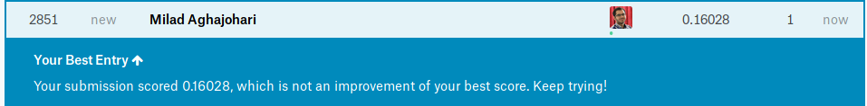